# GENEX

Sandra Erdmann

15 April 2019

# Genex project

## Introduction

I have one dependent or response variable (y), which is my gene expression and continuous. Then I have 2 explainatory or independent (x) variables or predictors (CO@ and Nutrients) in 4 treatments, which are categorical. These are described in the variable “sample” 380, 380+, 1000 and 1000+ or treatment A, B, C and D with Low and High for both factors CO2 and nutrients. So, I have combinatory effects of CO2 (2 factors) and nutrient levels (2 factors) on the expression rate.

In this case I have a mixed model effect (?) and need to run a **two-way ANOVA**

This are the assumptions to test ahead:

```
1) Individuals are independent.
2) Variance is homogeneous (seen in a boxplot; compute Levene's test).
3) Residuals follow a normal distribution (alternative non-parametric tests)?
4) At least 20 individuals (recommended), which I don't have!
```

NEW Approaches:

```
- better use a boxplot rather than a histogram, when small sample size
- nonparametric test, such as Fisher's Exact test (for small sample sizes), IF data is truely non normal
- compute an ANOVA for control vs. HCO2 + control vs. HNUT; HCO2 * HNUT
- apply point-biserial correlation coefficient and phi
- and non parametric fisher's exact test with your small data set. p.196
```

Questions:

```
  - Does poisson assume normality? Then better use nlme, which doesn't?
```

## Load libraries

```r
library(broom)
library(car)
library(coda)
library(effects)
```

```r
library(emmeans)
library(ggplot2)
library(ggfortify)
library(glmmTMB) # to fit a glmmTMB
library(lme4) #to fit a lme and lmer
library(mgcv) # for the function GAM
library(MASS)
library(mixtools) # to analyse bimodal distribution
library(MuMIn)
library(splines) # for using splines
library(vegan)
library(tidybayes)
library(tidyverse)
```

## Data arrangement

### Load dataset

```r
Genex<-read.csv('C:/Users/admin/Desktop/Paper CA/Gex/Genex.csv', strip.white=T)
Genex
```

```
##       Treat CO2 NUT         Exp
## 1  Standard         2115.760660
## 2  Standard         2024.672102
## 3  Standard         1613.727907
## 4  Standard         1708.051368
## 5  Standard          896.706108
## 6  Standard          612.440942
## 7  Standard          150.902801
## 8  Standard          100.559663
## 9  Standard            5.588431
## 10 Standard            3.054433
## 11      380   L   L 2037.972390
## 12      380   L   L 1687.230951
## 13      380   L   L 1894.012755
## 14      380   L   L 1777.995764
```

[output cut: 32 more lines]

### Explore dataset

```r
str(Genex)
```

```
## 'data.frame':    46 obs. of  4 variables:
##  $ Treat: Factor w/ 5 levels "1000","1000+",..: 5 5 5 5 5 5 5 5 5 5 ...
##  $ CO2  : Factor w/ 3 levels "","H","L": 1 1 1 1 1 1 1 1 1 1 ...
##  $ NUT  : Factor w/ 3 levels "","H","L": 1 1 1 1 1 1 1 1 1 1 ...
##  $ Exp  : num  2116 2025 1614 1708 897 ...
```

```r
summary(Genex)
```

```
##       Treat    CO2    NUT         Exp
##  1000    : 9    :10    :10   Min.   :   3.054
##  1000+   : 9   H:18   H:18   1st Qu.:1795.627
##  380     : 9   L:18   L:18   Median :2022.339
##  380+    : 9                 Mean   :1797.512
##  Standard:10                 3rd Qu.:2158.517
##                              Max.   :2324.306
```

## Sort dataset

Drop rows in the column “Sample” that do not contain a treatment. The samples, that don’t contain a treatment, are the ones that have the standard included. But I don’t want to check on the standard, so I drop this.

```r
arrange(Genex, Treat)
```

```
##       Treat CO2 NUT         Exp
## 1      1000   H   L 2283.356845
## 2      1000   H   L 2324.306081
## 3      1000   H   L 2312.887446
## 4      1000   H   L 2100.074986
## 5      1000   H   L 2122.250544
## 6      1000   H   L 2194.706455
## 7      1000   H   L 1815.089074
## 8      1000   H   L 1806.385982
## 9      1000   H   L 1795.380680
## 10    1000+   H   H 1919.512225
## 11    1000+   H   H 1884.732617
## 12    1000+   H   H 1796.367142
## 13    1000+   H   H 2258.665373
## 14    1000+   H   H 2186.725071
```

[output cut: 32 more lines]

Drop Samples with no treatment aligned

```r
Genex1<-filter(Genex, Treat %in% c('380','380+','1000','1000+')) %>% droplevels()
Genex1
```

```
##    Treat CO2 NUT      Exp
## 1    380   L   L 2037.972
## 2    380   L   L 1687.231
## 3    380   L   L 1894.013
## 4    380   L   L 1777.996
## 5    380   L   L 1853.523
## 6    380   L   L 1841.867
## 7    380   L   L 2127.579
## 8    380   L   L 2263.130
## 9    380   L   L 2256.973
## 10  380+   L   H 2020.006
## 11  380+   L   H 2147.816
## 12  380+   L   H 2168.967
## 13  380+   L   H 2080.946
## 14  380+   L   H 2162.084
```

[output cut: 22 more lines]

Note:

```
Genex includes the standard
Genex1 does not contain the standard
```

## Descriptive Statistics

Visualize the dataset

### Gene expression by treatment

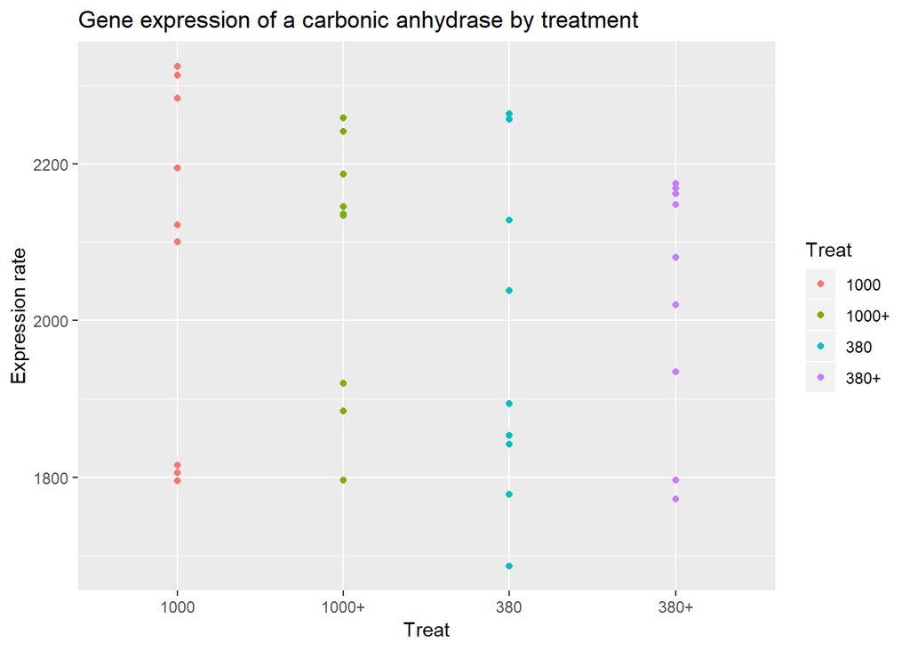

```r
ggplot(Genex1, aes(x=Treat, y=Exp, group=Treat, color=Treat)) +
  geom_point(aes(x=Treat,y=Exp, colour=Treat)) +
       ggtitle("Gene expression of a carbonic anhydrase by treatment") +
    scale_y_continuous(name="Expression rate")
```

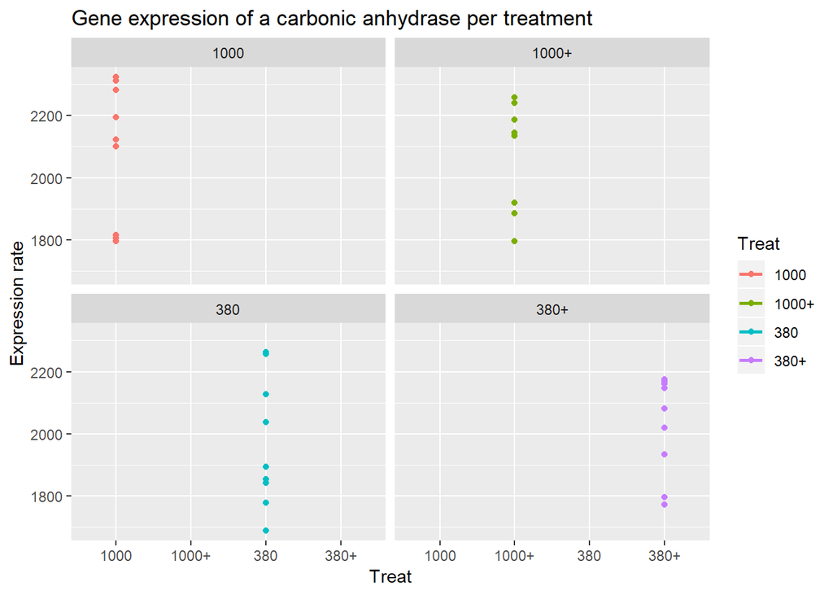

```r
ggplot(Genex1, aes(y=Exp, x=Treat, group=Treat, color=Treat)) +
  geom_point()+
       ggtitle("Gene expression of a carbonic anhydrase per treatment") +
    scale_y_continuous(name="Expression rate") +
  geom_smooth(method='lm', se=FALSE) +
  facet_wrap(~Treat)
```

### Impact of CO2

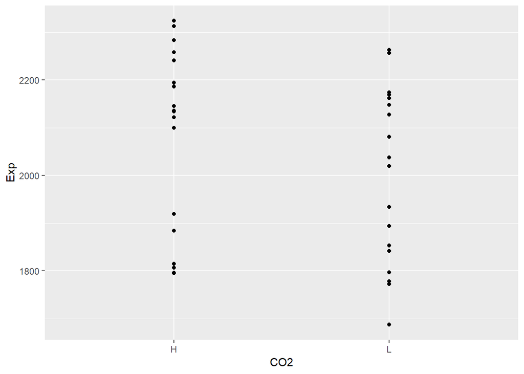

```r
ggplot(Genex1, aes(y=Exp, x=CO2)) +
        geom_point()
```

### Impact of Nut

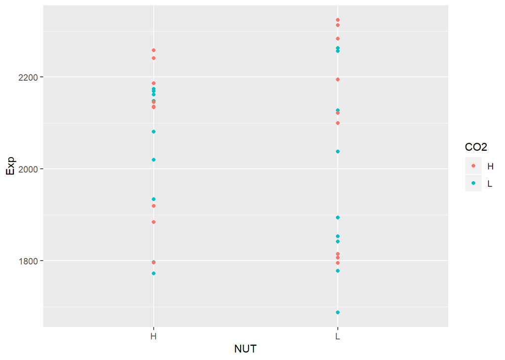

```r
ggplot(Genex1, aes(y=Exp, x=NUT, colour=CO2)) +
        geom_point()
```

### Mean, variance and SD

What is the mean, variance and SD **of entire dataset**?

```r
summary(Genex1)
```

```
##    Treat   CO2    NUT         Exp
##  1000 :9   H:18   H:18   Min.   :1687
##  1000+:9   L:18   L:18   1st Qu.:1851
##  380  :9                 Median :2111
##  380+ :9                 Mean   :2040
##                          3rd Qu.:2177
##                          Max.   :2324
```

```r
summarise(Genex1, Mean=mean(Exp), Variance=var(Exp), SD=sd(Exp))
```

```
##       Mean Variance       SD
## 1 2040.391 35685.04 188.9048
```

What is the **mean** of each treatment?

```r
tapply(Genex1$Exp, INDEX=Genex1$Treat, FUN=mean)
```

```
##     1000    1000+      380     380+
## 2083.826 2077.998 1971.143 2028.596
```

What is the **variance** of each treatment?

```r
tapply(Genex1$Exp, INDEX=Genex1$Treat, FUN=var)
```

```
##     1000    1000+      380     380+
## 49567.57 27980.14 43787.70 25521.82
```

What is the **standard deviation** of each treatment?

```r
tapply(Genex1$Exp, INDEX=Genex1$Treat, FUN=sd)
```

```
##     1000    1000+      380     380+
## 222.6377 167.2727 209.2551 159.7555
```

## Assumption 1

### Individuals are independent:

How? By **centering** predictors, the interaction is independent. Use function center.

## Assumption 2

### Variance is homogeneous

**Homogeneity** is checked by validating a **boxplot**.

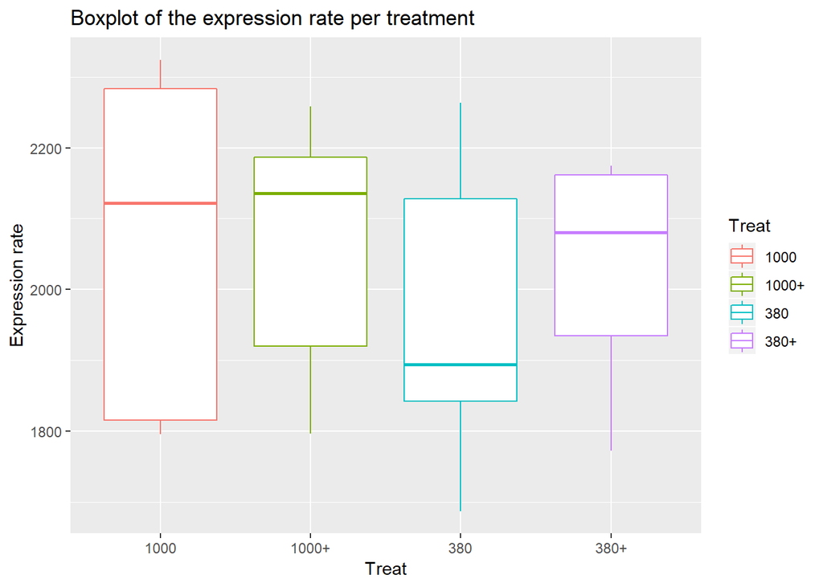

```r
ggplot(Genex1, aes(x=Treat, y=Exp, group=Treat, color=Treat)) +
  geom_boxplot() +
    ggtitle("Boxplot of the expression rate per treatment") +
    scale_y_continuous(name="Expression rate")
```

Result: The mean is not always in the middle. I have homogeneity since there is no relation between the mean and the variance visible in the boxplot. When the mean is greater, the variance is not equally getting bigger.

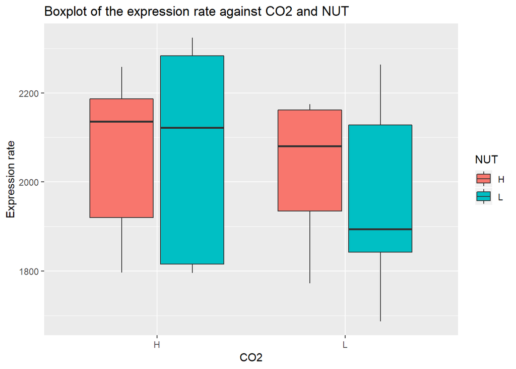

```r
ggplot(Genex1, aes(x=CO2, y=Exp, fill=NUT)) +
  geom_boxplot() +
    ggtitle("Boxplot of the expression rate against CO2 and NUT") +
    scale_y_continuous(name="Expression rate")
```

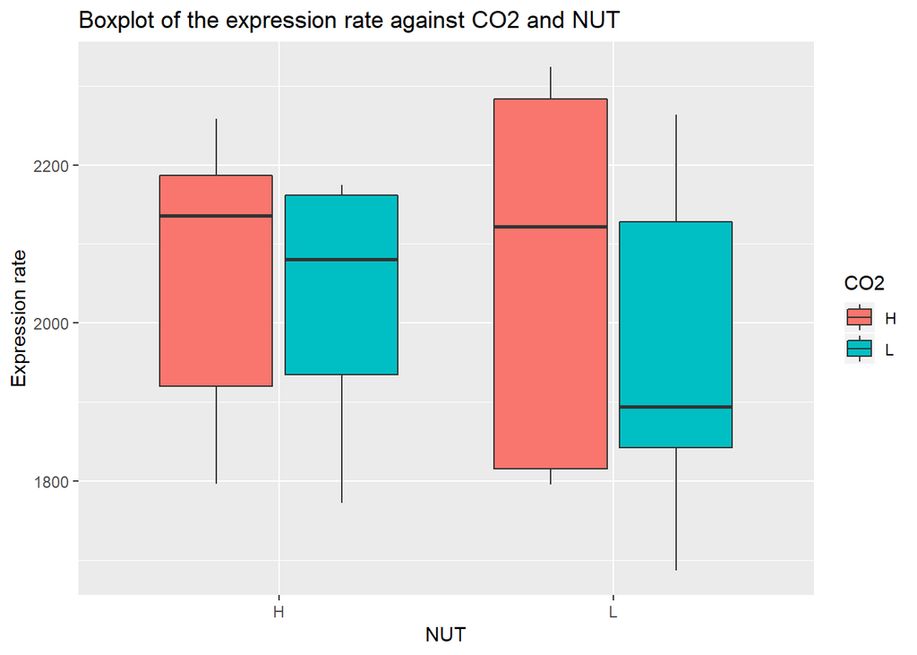

```r
ggplot(Genex1, aes(x=NUT, y=Exp, fill=CO2)) +
  geom_boxplot() +
    ggtitle("Boxplot of the expression rate against CO2 and NUT") +
    scale_y_continuous(name="Expression rate")
```

## Assumption 3

### Residuals follow a normal distribution

```r
#Genex1<-filter(Genex, Treat %in% c('380','380+','1000','1000+')) %>% droplevels()
#Genex1
```

residuals and Y should be normally distributed

The distribution of Y within each group should be normally distributed

So in ANOVA, you actually have two options for testing normality. If there really are many values of Y for each value of X (each group), and there really are only a few groups (say, four or fewer), go ahead and check normality separately for each group.

But if you have many groups (a 2x2x3 ANOVA has 12 groups) or if there are few observations per group (it’s hard to check normality on only 20 data points), it’s often easier to just use the residuals and check them all together.

If you have a continuous covariate in the model as well, you’ve just lost option one, and residuals are the only way to go.

All GLM procedures have an option to save residuals. Once you do, run the same QQ plots to check normality as you would in regression.

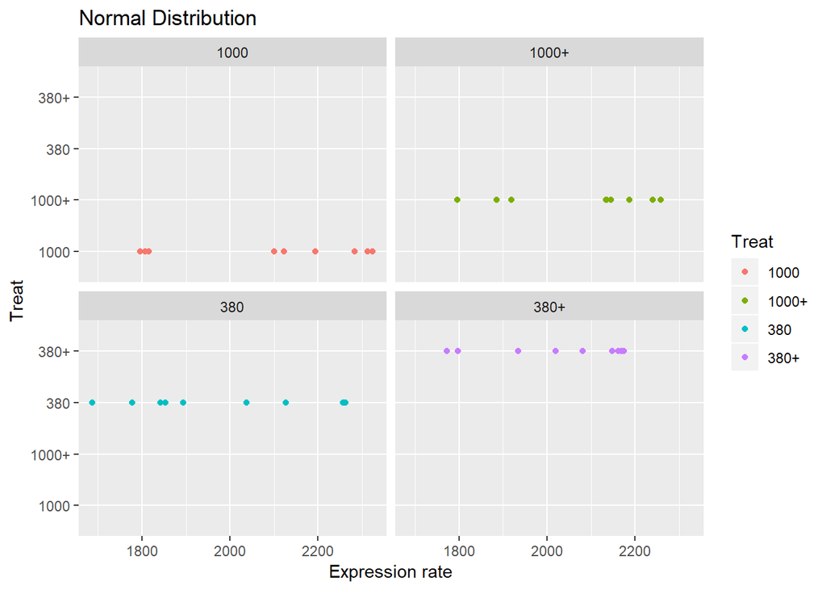

```r
ggplot(Genex1, aes(x=Exp, y=Treat, color=Treat)) +
  geom_point() +
       ggtitle("Normal Distribution") +
    scale_x_continuous(name="Expression rate") +
  facet_wrap(~Treat)
```

Change x to expression rate and x to count. maybe sort by low to high.

Is my data normally distributed? Test this with a shapiro test

```r
shapiro.test(Genex1$Exp)
```

```
##
##  Shapiro-Wilk normality test
##
## data:  Genex1$Exp
## W = 0.91811, p-value = 0.01108
```

Result: If the chosen alpha level is 0.05 and the p-value is less than 0.05, then the null hypothesis that the data are normally distributed is rejected. So, the data are **not normally distributed**.

Confirm with the Anderson-Darling test

```r
library(nortest)
ad.test(Genex1$Exp)
```

```
##
##  Anderson-Darling normality test
##
## data:  Genex1$Exp
## A = 1.1634, p-value = 0.004204
```

Result: If the chosen alpha level is 0.05 and the p-value is less than 0.05, then the null hypothesis that the data are normally distributed is rejected. So, the data are **not normally distributed**.

## Inferential Statistics

### ANOVA

1. Fit model

**Gaussian**

Poisson is for integers only.

```r
Genex1.glm<-glm(Exp~CO2*NUT, data=Genex1, family=gaussian)
```

Check on **coefficients** of the linear model:

```r
coef(Genex1.glm)
```

```
## (Intercept)        CO2L        NUTL   CO2L:NUTL
##  2077.99809   -49.40214     5.82836   -63.28170
```

Check on **residuals** of the linear model:

```r
r<-residuals(Genex1.glm)
r
```

```
##          1          2          3          4          5          6
##   66.82977 -283.91167  -77.12986 -193.14686 -117.61983 -129.27590
##          7          8          9         10         11         12
##  156.43617  291.98746  285.83071   -8.58963  119.21988  140.37111
##         13         14         15         16         17         18
##   52.35036  133.48795  145.72472 -256.48176 -231.74455  -94.33808
##         19         20         21         22         23         24
##  199.53039  240.47963  229.06099   16.24853   38.42409  110.88000
##         25         26         27         28         29         30
## -268.73738 -277.44047 -288.44577 -158.48587 -193.26548 -281.63095
##         31         32         33         34         35         36
##  180.66728  108.72698  163.13303   57.41148   55.97753   67.46601
```

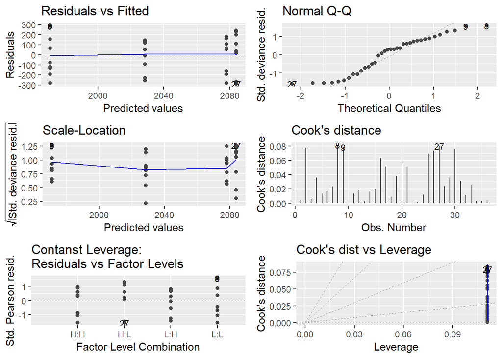

```r
autoplot(Genex1.glm, which=1:6, ncol=2, label.size=3)
```

Result:

```
Residuals ok; we can ignore stripy pattern, since this reflects the factorial design
Normal QQ has tails? so my data is not normally distributed? log transform
Cook's D is acceptabel, since less than 0.8
```

**Goodness of fit test**

```r
Genex1.resid=sum(resid(Genex1.glm, type='pearson')^2)
1-pchisq(Genex1.resid, df=Genex1.glm$df.residual)
```

```
## [1] 0
```

```r
# small p-value, so there is evidence of lack of fit
```

Result: lack of fit -> non normality -> log transform

**Log-Transformation**

```r
Genex2.glm<-glm(log(Exp)~CO2*NUT, data=Genex1, family=gaussian)
```

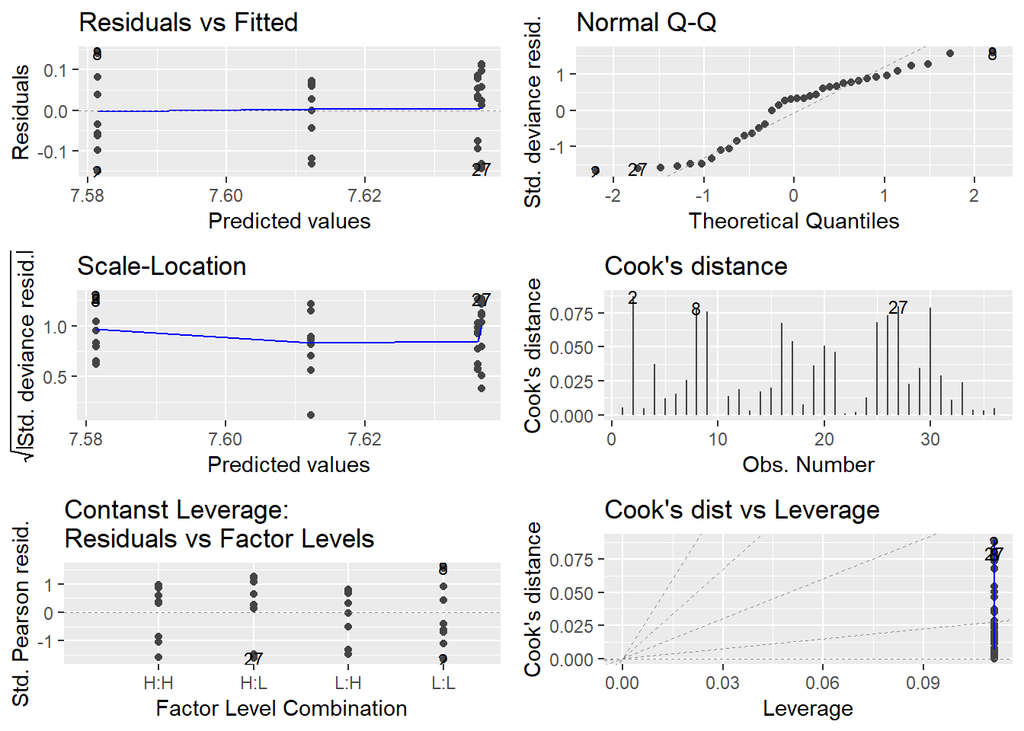

```r
autoplot(Genex2.glm, which=1:6, ncol=2, label.size=3)
```

```r
AICc(Genex1.glm, Genex2.glm)
```

```
##            df      AICc
## Genex1.glm  5 488.31657
## Genex2.glm  5 -59.18794
```

Result: How can I get a negative AIC???

```r
Genex2.resid<-sum(resid(Genex2.glm, type="pearson")^2)
1-pchisq(Genex2.resid, Genex2.glm$df.resid)
```

```
## [1] 1
```